# Moras Azules

Jaidy Adzuira Pineda Aguilar

8 de marzo de 2021

Naturaleza: La mora azul o mora de castilla es una fruta perteneciente al grupo de las bayas. Se destaca de otras frutas por su alto contenido en vitamina C y provitamina A, aparte de ser baja en azúcar y tener fibra y agua en abundancia. De tal manera la mora azul es una baya que cuenta con un valor nutricional destacable, tan solo comer 100gr de esta baya proporciona 39Kcal, fibra 6.6g, potación 160mg, hidratos de carbono 5,1g y vitamina C 15mg. Sin embargo, las moras azules cuentan con múltiples beneficios para la salud tales como: la prevención del cáncer, mejora la circulación sanguínea, aumentan el colesterol HDL y bajan el LDL, de igual forma mejoran la capacidad cerebral, y es baja en azucares, por lo que es muy recomendada para bajar de peso.

Valor de uso: La mora azul es un producto agropecuario que satisface diversas necesidades a la población que la consume, generalmente a la necesidad del alimento, por lo que las moras azules son consumidas a gran escala en todo el mundo. Sin embargo, de igual forma cumple con otras necesidades humanas tales como: la producción de mascarillas, cremas, shampoo, siendo de esta forma que la mora azul se desenvuelve en diversas industrias para la satisfacción de necesidades humanas.

Valor de cambio: Su valor de cambio se ve reflejado en la comercialización de este producto, México es el 4º productor a nivel mundial de moras azules contribuyendo con 6.1%, el cual exporta a 32 países, de los cuales destacan: Japón, Estados Unidos, Holanda, Canadá y Reino unido. De esta manera los principales estados productores en México son: Jalisco, Sinaloa, Michoacán, Baja california y Colima. En el 2018 México exporto 36080 toneladas de moras azules, donde el 40.95% se destina al mercado internacional, siendo superior a otros países productores.

Valor: En México la exportación de moras azules (incluyendo las demás frutas de bosques, frambuesa y zarzamora) contribuyen el 2.15% del PIN agrícola nacional y el 1.83% de la producción de frutas (SIAP 2017). Su producción ha ido en aumento desde 2003-2016 con una producción total de 390239 toneladas y un crecimiento anual promedio de 21.8%, de esta forma se estima que la producción y demanda de moras azules y frutos del bosque aumente considerablemente para 2030, donde México podrá ampliar su mercado Internacional (estimación de consumo nacional aparente 2013 por CONAPO).

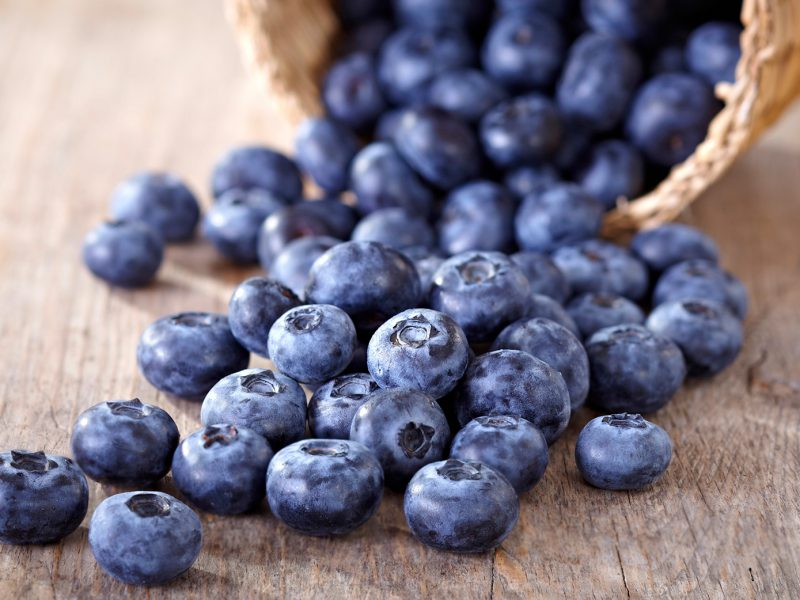

Fuente: https://www.saltillo360.com/conoce-las-razones-comer-moras-azules

## Bibliografía

1. https://www.infoagro.com/documentos/el_cultivo_mora__parte_i_.asp#:~:text=Al%20momento%20de%20la%20siembra,y%201.7%20a%202.0%20m.
2. https://consumidoresorganicos.org/2018/09/19/las-moras-azules-pueden-mejorar-capacidad-cerebral/
3. https://alimentossaludables.mercola.com/moras-azules.html

4.http://cea.uanl.mx/mexico-exportara-mora-azul-a-china-es-el-cuarto-productor-a-nivel-mundial/

5.https://www.gob.mx/cms/uploads/attachment/file/257076/Potencial-Frutas_del_Bosque.pdf